# Chapter 2. Basic UI

Zhenhua Xu

*This is the study note following reading the book “Mastering Shiny” by Hadley Wickham.*

# 1 Introduction

From the first chapter, we can tell that Shiny encourages separation of the code that generates the user interface (the front end) from the code that drives the app’s behaviour (the back end).

In this chapter, we’ll focus on the front end, to explore the HTML inputs and outputs provided by Shiny. So that we would be able to have the ability to capture many types of data and display many types of R output.

Most of the examples will be stick to the Shiny built-in input and output. However, there is a rich and vibrant community of extension packages like **shinyWidgets**, **colorpicker**, and **sorttable**. A comprehensive, actively-maintained list of other packages can also be found at https://github.com/nanxstats/awesome-shiny-extensions

As usual, we begin by loading the shiny package:

```r
library(shiny)
```

# 2 Inputs

So far, we have seen functions like `sliderInput()`, `selectInput()`, and textInput()` that we use to insert input controls into the UI. Let’s see the common structure that underlies all input funtions and give a quick overview of the inputs built into Shiny.

## 2.1 Common structure

All input functions have the same **first argument: `inputId`**, this is **the identifier used to connect the front end with the back end**. For example, if the UI has an input with ID `"name"`, then the server function will access it with `input$name`.

**Two constraints for `inputId`:**

- **Must be a simple string that contains only letters, numbers and underscore. Try to name it with sense.**
- **Must be unique. Otherwise you’ll have no way to refer to this control in the server function.**

Most input functions have a **second parameter called `label`**, to assist people understanding the input control.

The **third parameter is typically `value`**, which, where possible, lets you **set the default value**.

The remaining parameters for each control are unique to that specific input control.

It is recommanded by providing the **`inputId` and `label` arguments by position**, and **all other arguments by name**:

```r
sliderInput("min", "Limit (minimum)", value = 50, min = 0, max = 100)
```

## 2.2 Free text

Collect **small amounts of text** with `textInput()`, **passwords** with `passwordInput()` , and **paragraphs of text** with `textAreaInput()`. For example:

```r
ui <- fluidPage(
  textInput("name", "What's your name?"),
  passwordInput("password", "What's your password?"),
  textAreaInput("story", "Tell me about yourself", rows = 3)
)
```

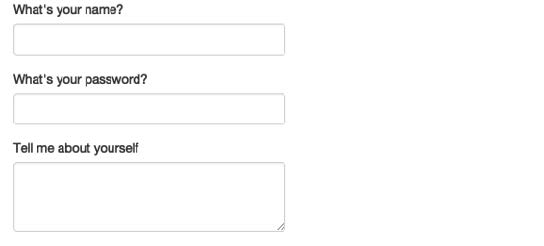

You can use `validate()` to check if the text has certain properties, which will be discussed in detail in Chapter 8.

## 2.3 Numeric inputs

To collect **numeric values**, create a *constrained text box* with `numericInput()` or a *slider* with `sliderInput()`. If you *supply a length-2 numeric vector for the default value* of `sliderInput()`, you get a *“range” slider with two ends*.

```r
ui <- fluidPage(
  numericInput("num", "Number one", value = 0, min = 0, max = 100),
  sliderInput("num2", "Number two", value = 50, min = 0, max = 100),
  sliderInput("rng", "Range", value = c(10, 20), min = 0, max = 100)
)
```

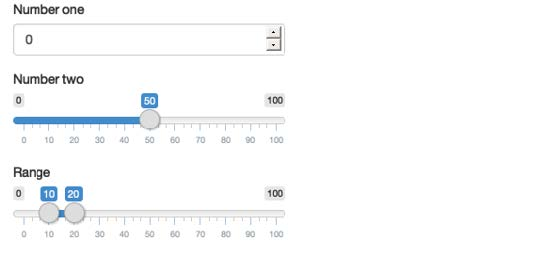

It is recommanded to only using sliders for small ranges, or cases where the precise value is not so important, as it is not always easy to control a small slider to precisely select a number.

Sliders are extremely customisable and there are many ways to tweak their appearance. See ?sliderInput and https://shiny.rstudio.com/articles/sliders.html for more details.

## 2.4 Dates

Collect **a single day** with `dateInput()` or **a range between two days** with `dateRangeInput()`. These provide a convenient calendar picker, and additional arguments like `datesdisabled` and `daysofweekdisabled` allow you to restrict the set of valid inputs.

```r
ui <- fluidPage(
  dateInput("dob", "When were you born?"),
  dateRangeInput("holiday", "When do you want to go on vacation next?")
)
```

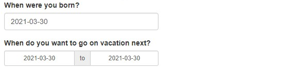

The default date that displays is the date one runs the app.

Date format, language, and the day on which the week starts **defaults to US standards**. If you are creating an app with an international audience, set `format`, `language`, and `weekstart` so that the dates are natural to your users.

## 2.5 Limited choices

There are two different approaches to allow the user to choose from a prespecified set of options: `selectInput()` and `radioButtons()`.

```r
animals <- c("dog", "cat", "mouse", "bird", "other", "I hate animals")
ui <- fluidPage(
  selectInput("state", "What's your favourite state?", state.name),
  radioButtons("animal", "What's your favourite animal?", animals)
)
```

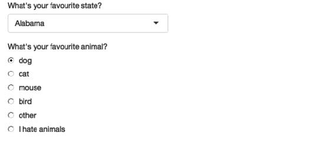

Radio buttons have two nice features: they show all possible options, making them suitable for short lists, and via the `choiceNames/choiceValues` arguments, they can display options other than plain text. **`choiceNames` determines what is shown to the user; `choiceValues` determines what is returned in your server function**.

```r
ui <- fluidPage(
  radioButtons("rb", "Choose one:",
    choiceNames = list(
      icon("angry"),
      icon("smile"),
      icon("sad-tear")
    ),
    choiceValues = list("angry", "happy", "sad")
  )
)
```

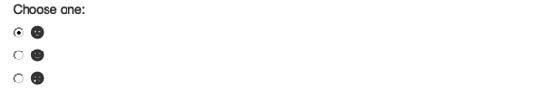

Dropdowns created with `selectInput()` take up the same amount of space, regardless of the number of options, making them more **suitable for longer options**. You can also set `multiple = TRUE` to **allow the user to select multiple elements**.

```r
ui <- fluidPage(
  selectInput(
    "state", "What's your favourite state?", state.name,
    multiple = TRUE
  )
)
```

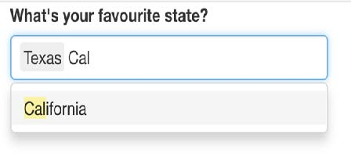

For very large set of possible options, it would be a good choice to use “server-side” `selectInput()` so that we don’t embed the complete set of possible options in the UI, in order to avoid making it slow to load; instead we can send them as needed by the server. To learn more about this advanced topic, go to: https://shiny.rstudio.com/articles/selectize.html#server-side-selectize

We can’t select multiple values with radio buttons, but we can use `checkboxGroupInput()`

```r
ui <- fluidPage(
  checkboxGroupInput("animal", "What animals do you like?", animals)
)
```

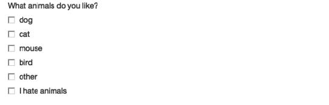

For a single checkbox for a single yes/no question, we can use `checkboxInput()`

```r
ui <- fluidPage(
  checkboxInput("cleanup", "Clean up?", value = TRUE),
  checkboxInput("shutdown", "Shutdown?")
)
```

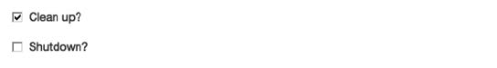

## 2.6 File uploads

Allow the user to upload a file with `fileInput()`

```r
ui <- fluidPage(
  fileInput("upload", NULL)
)
```

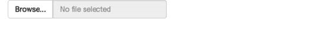

`fileInput()` requires special handling on the server side, which will be learned in Chapter 9.

## 2.7 Action buttons

Let user perform an action using `actionButton()` or `actionLink()`:

```r
ui <- fluidPage(
  actionButton("click", "Click me!"),
  actionButton("drink", "Drink me!", icon = icon("cocktail"))
)
```

Action links and buttons are most naturally paired with `observeEvent()` or `eventReactive()` in the server function. We will learn these functions later.

We can customise the buttons using the `class` argument. The `class` argument works by setting the `class` attribute of the underlying HTML, which affects how the element is styled. These values can be assigned to `class` argument: to change the apparance with `"btn-primary"`, `"btn-success"`, `"btn-info"`, `"btn-warning"`, or `"btn-danger"`; to change the size with `"btn-lg"`, `"btn-sm"`, `"btn-xs"` and fianlly to make buttons span the entire width of the element they are embedded within using `"btn-block"`.

```r
ui <- fluidPage(
  fluidRow(
    actionButton("click", "Click me!", class = "btndanger"),
    actionButton("drink", "Drink me!", class = "btn-lg btnsuccess")
  ),
  fluidRow(
    actionButton("eat", "Eat me!", class = "btn-block")
  )
)
```

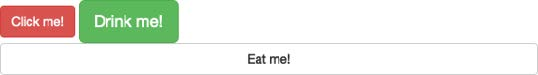

## 2.8 Exercises 1

**1. When space is at a premium, it’s useful to label text boxes using a placeholder that appears *inside* the text entry area. How do you call `textInput()` to generate the UI below?**

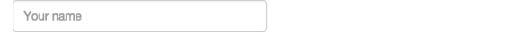

**Solution:**

```r
ui <- fluidPage(
  textInput("name", "", placeholder = "Your name")
)
```

**2. Carefully read the documentation for `sliderInput()` to figure out how to create a date slider, as shown below.**

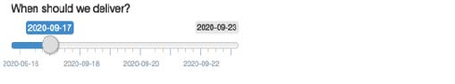

**Solution:**

```r
ui <- fluidPage(
  sliderInput("date", "When should we deliver?", min = as.Date("2020-09-16"),
              max = as.Date("2020-09-23"), value = as.Date("2020-09-17"),
              timeFormat = "%F"
  )
)
```

**3. Create a slider input to select values between 0 and 100 where the interval between each selectable value on the slider is 5. Then, add animation to the input widget so when the user presses play the input widget scrolls through the range automatically.**

**Solution:**

```r
ui <- fluidPage(
  sliderInput("number", "Automatic Number Selector", min = 0, max = 100,
              value = 0, step = 5,
              animate = animationOptions(interval = 500, loop = TRUE,
                                         playButton = "Auto scroll"
              )
  )
)
```

**4. If you have a moderately long list in a selectInput(), it’s useful to create sub-headings that break the list up into pieces. Read the documentation to figure out how. (Hint: the underlying HTML is called `<optgroup>`.)**

**Solution:**

```r
ui <- fluidPage(
  selectInput("Provience", "Choose a Province:",
    list('North' = list("YK", "NT", "NU"),
         'West' = list("BC", "AB", "MB"),
         'South' = list("ON", "QB"),
         'East' = list("NL", "NB", "NS", "PEI"))
  )
)
```

# 3 Outputs

Outputs in the UI create placeholders that are later filled by the server function. outputs takes a unique ID as their first argument. E.g. if your UI creates an output with ID `"plot"`, then we will access it in the server function with `output$plot`.

**Each `output` function in the front end is coupled with a `render` function in the back end.** There are *many types of output*, corresponding to the *three things* we usually include in a report: **text**, **table**, and **plots**.

Here are the basics of the output functions on the front end, along with the corresponding `render` functions in the back end.

## 3.1 Text

Output regular text with `textOutput()` and fixed (font width) code and console output with `verbatimTextOutput()`

```r
ui <- fluidPage(
  textOutput("text"),
  verbatimTextOutput("code")
)

server <- function(input, output, session) {
  # textOutput() corresponds to renderText()
  output$text <- renderText({
    "Hello friend!"
  })

  # verbatimTextOutput() corresponds to renderPrint()
  output$code <- renderPrint({
    summary(1:10)
  })
}
```

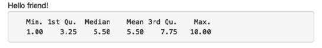

Note that the `{}` are only required in `render` functions if you need to run multiple lines of code. Therefore, we can write the server function more compactly:

```r
server <- function(input, output, session) {
  output$text <- renderText("Hello friend!")
  output$code <- renderPrint(summary(1:10))
}
```

**Note:**

- `renderText()` combines the result into a single string, and is usually paired with `textOutput()`.
- `renderPrint()` *prints* the results, as if you were in an R console, and the printout fond is monospaced (fixed width). It is usually paired with `verbatimTextOutput()`.  
  For example:

```r
ui <- fluidPage(
  textOutput("text"),
  verbatimTextOutput("print")
)
server <- function(input, output, session) {
  output$text <- renderText("hello!"),
  output$print <- renderPrint("hello!")
}
```

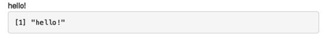

This is equivalent to the difference between `cat()` and `print()` in base R.

## 3.2 Tables

Two options for displaying data frames in tables in Shiny:

- `tableOutput()` and `renderTable()` render a static table of data, showing all the data at once.
- `dataTableOutput()` and `renderDataTable()` render a dynamic table, showing a fixed number of rows along with controls to change which rows are visible.

Therefore, `tableOutput()` is most useful for small, fixed summaries; whereas `dataTableOutput()` is most appropriate if we want to expose a complete data frame to the user.

We can get greater control over the output of `dataTableOutput()` with `reactable` package by Greg Lin.

```r
ui <- fluidPage(
  tableOutput("static"),
  dataTableOutput("dynamic")
)

server <- function(input, output, session) {
  output$static <- renderTable(head(mtcars))
  output$dynamic <- renderDataTable(mtcars, options = list(pageLength = 5))
}
```

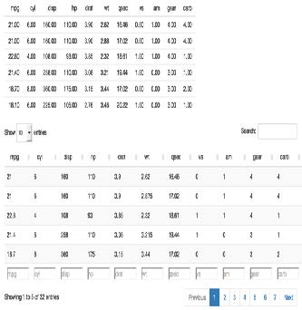

## 3.3 Plots

We can display any type of R graphic (base, ggplot2, or others) with `plotOutput()` and `renderPlot()`:

```r
ui <- fluidPage(
  plotOutput("plot", width = "400px")
)

server <- function(input, output, session) {
  output$plot <- renderPlot(plot(1:5), res = 96)
}
```

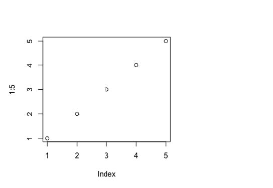

By default, `plotOutput()` will take up the **full width** of its container, and will be **400 pixels high**. We can override these defaults with the `height` and `width` arguments. We recommend **always setting `res = 96`** as that will make the Shiny plots match what you see in RStudio as closely as possible.

## 3.4 Downloads

We can allow the user download a file with `downloadButton()` or `downloadLink()`. We will learn this in Chapter 9 as these require new techniques in the server function.

## 3.5 Exercises 2

**1. Which of `textOutput()` and `verbatimTextOutput()` should each of the following render functions be paired with?**

1. **renderPrint(summary(mtcars))**
2. **renderText(“Good morning!”)**
3. **renderPrint(t.test(1:5, 2:6))**
4. **renderText(str(lm(mpg ~ wt, data = mtcars)))**

**Solution:**

1. `verbatimTextOutput()`
2. `textOutput()`
3. `verbatimTextOutput()`
4. `textOutput()`

**2. Re-create the Shiny app from “Plots”, this time setting height to 300px and width to 700px. Set the plot “alt” text so that a visually impaired user can tell that its a scatterplot of five random numbers.**

```r
library(shiny)
ui <- fluidPage(
  plotOutput("plot", width = "700px", height = "300px")
)

server <- function(input, output, session) {
  output$plot <- renderPlot(plot(1:5), res = 96, alt = " This is a scatterplot with five random numbers")
}

shinyApp(ui, server)
```

**3. Update the options in the call to `renderDataTable()` below so that the data is displayed, but all other controls are suppress (i.e. remove the search, ordering, and filtering commands). You’ll need to read `?renderDataTable` and review the options at https://datatables.net/reference/option/.**

```r
ui <- fluidPage(
  dataTableOutput("table")
)

server <- function(input, output, session) {
  output$table <- renderDataTable(mtcars, options = list(pageLength = 5))
}
```

**Solution:**

```r
library(shiny)

ui <- fluidPage(
  dataTableOutput("table")
)

server <- function(input, output, session) {
  output$table <- renderDataTable(
    mtcars, options = list(ordering = FALSE, searching = FALSE))
}

shinyApp(ui, server)
```

**4. Alternatively, read up on `reactable` package, and convert the above app to use it instead.**

**Solution:**

```r
library(shiny)
library(reactable)

ui <- fluidPage(
  reactableOutput("table")
)

server <- function(input, output, session) {
  output$table <- renderReactable(
    reactable(mtcars))
}

shinyApp(ui, server)
```